[output not shown]

Signif. codes: 0 ‘**’ 0.001 ’**’ 0.01 ’’ 0.05 ‘.’ 0.1 ’ ’ 1

Residual standard error: 0.8584 on 8 degrees of freedom Multiple R-squared: 0.807, Adjusted R-squared: 0.7588 F-statistic: 16.73 on 2 and 8 DF, p-value: 0.001386 This means that 80.7% of the variation in the TimeReading can be explained by the number of TimeTV and happiness.

## vii. Pick three variables and perform a partial correlation, documenting which variable you are “controlling”. Explain how this changes your interpretation and explanation of the results.

Answer: I used the following command to explaining the relationship between the three variables I picked: TimeTV, TimeReading and Happiness.

```r
pcor.test(x=Stdnt_Srvy_df$TimeReading, y=Stdnt_Srvy_df$TimeTV, z=Stdnt_Srvy_df$Happiness)
```

estimate p.value statistic n gp Method 1 -0.872945 0.0009753126 -5.061434 11 1 pearson The results show that the p value is low (0.000975) that means the two variables (TimeReading and TimeTV) are partially correlated. Control variable is Happiness. The results show that the estimate value of -0.8729 Partial Correlation shows a strong but opposite direction correlation and the pValue being small suggests the relationship between them highly statistically significant. Happiness is a mediating variable and partially explains the correlation between the TimeReading and TimeTV variables.

## Including Plots

The scatterplots I generated to show relationships between two variables are provided below:

### TimeTV vs. TimeReading

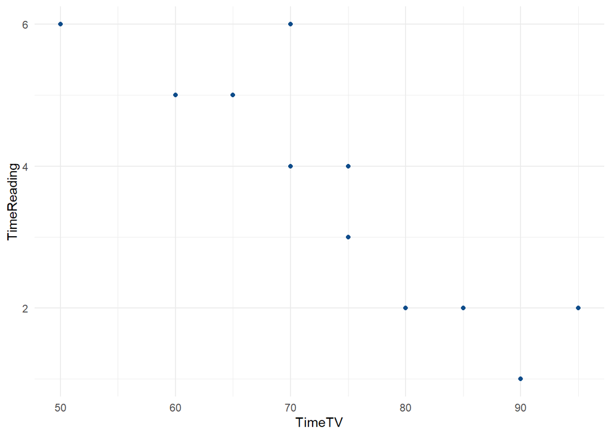

The above scatterplot between TimeTV and TimeReading shows a fairly strong negative relationship as sloping top left to bottom right.

### Happiness vs. TimeReading

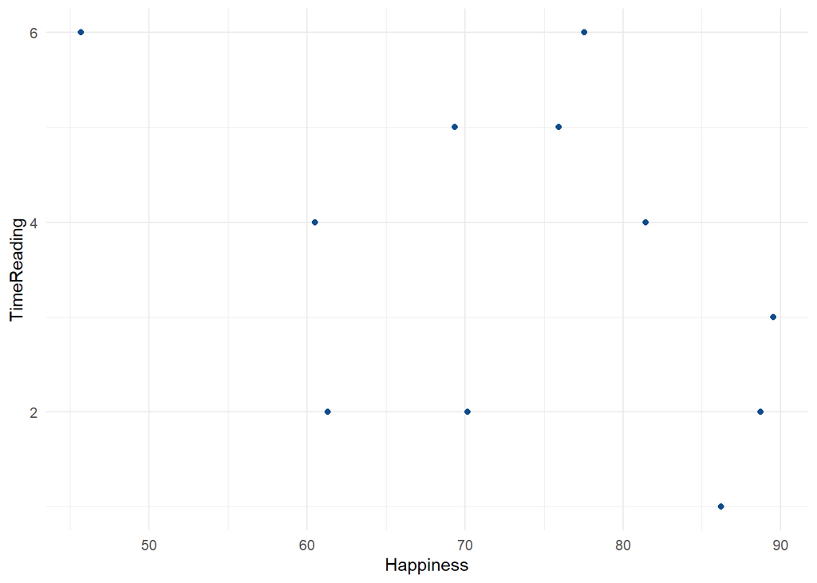

The above scatterplot between Happiness and TimeReading also shows somewhat a negative relationship as sloping top left to bottom right but data points are more scattered. Makes sense as the correlation coefficient above for these two variables is -0.434 compared to -0.883 which is much stronger and data more in closer to the straight line between TimeTV and TimeReading.

### Happiness vs. TimeTV

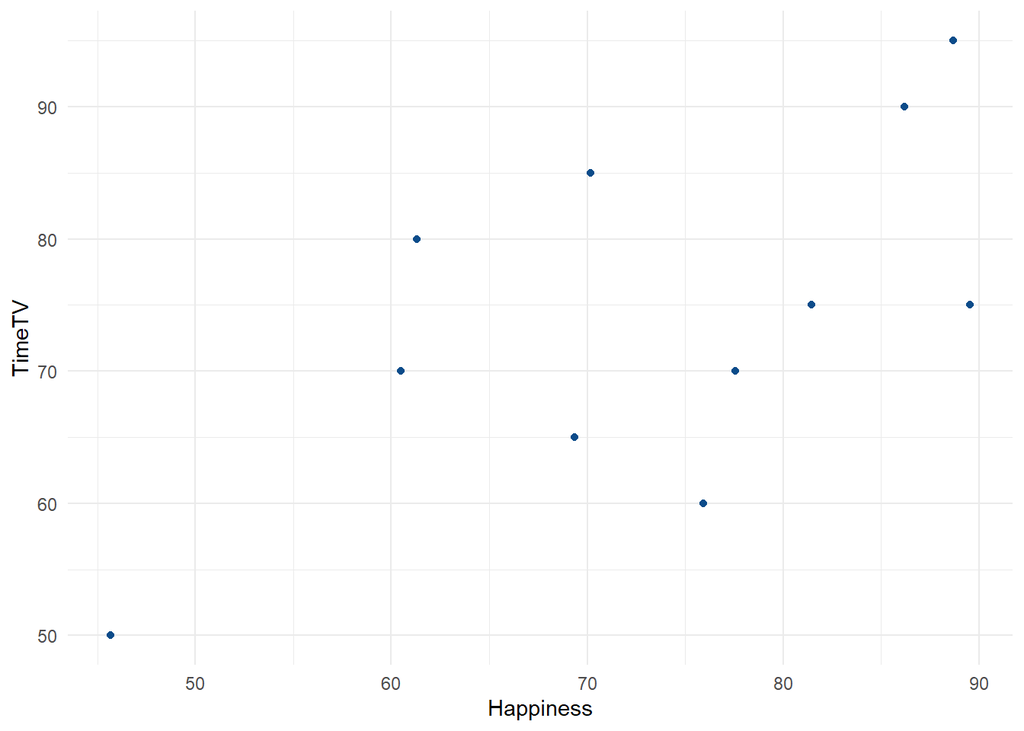

The above scatterplot between Happiness and TimeTV shows a positive relationship and data sloping up from lower left to top right. The correlation coefficient also suggests this positive relationship with 0.636. However not very strong. The scatterplot also shows spread of data around the path.

### Gender vs. TimeReading

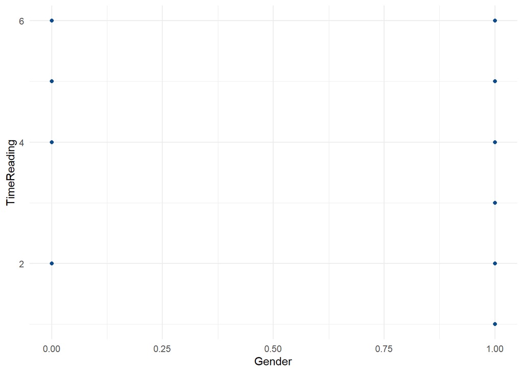

## ggqqplots

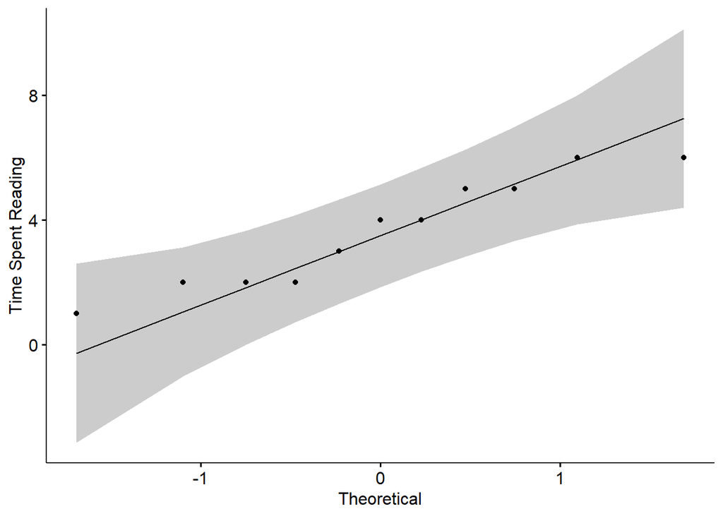

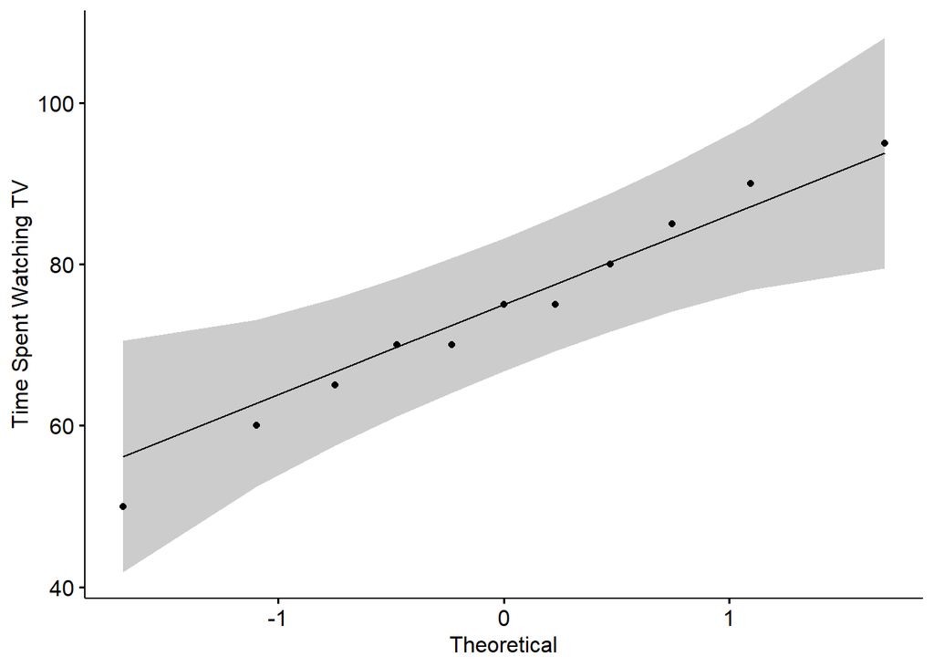

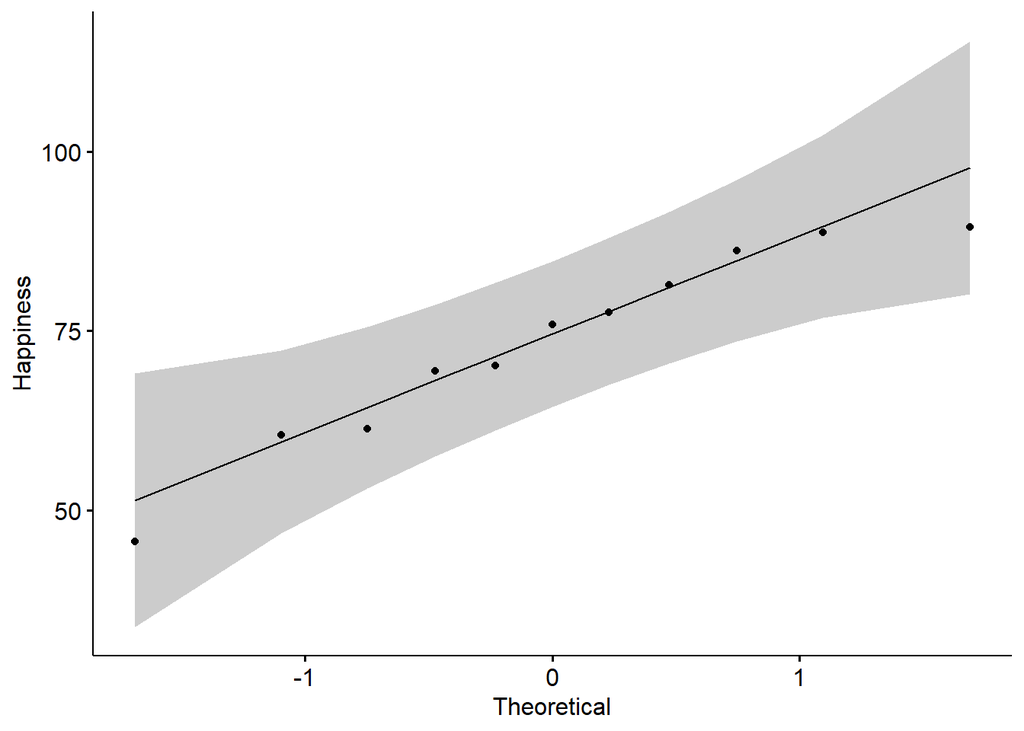

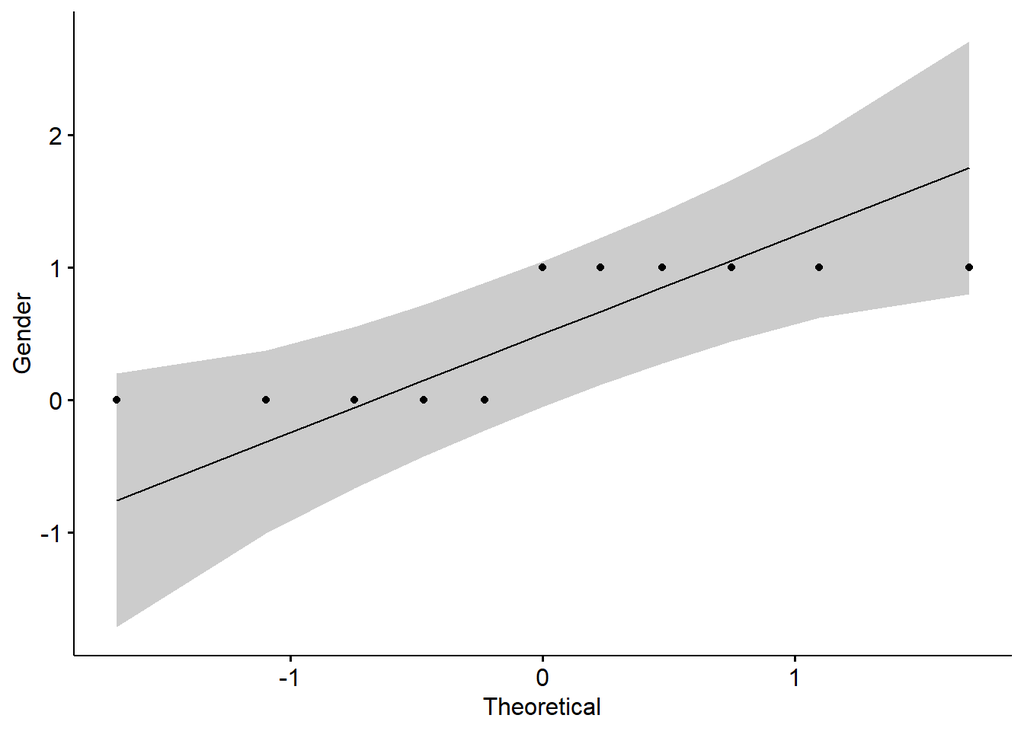

The ggqqplots above show that the TimeReading, TimeTV and Happiness data are linear.